# Exercise_three.R

zhian

Sat Nov 22 20:11:13 2014

# Exercise 3: third time’s to harm

This set of exercises will build off of exercise two, which was built off of exercise one. The purpose of this will be to utilize memoization and dynamic programming as alternative ways of solving the Nicholson-Bailey Model

## Necessary packages

```r
library(hash)
```

```r
library(stringr)
library(microbenchmark)
library(reshape2)
library(ggplot2)
```

## The Nicholson-Bailey Model

### Formulaic definition

$H_{t} = \gamma \cdot H_{t-1} \cdot e^{-a \cdot P_{t-1}}\\ P_{t} = H_{t-1} \cdot \left(1 - e^{-a \cdot P_{t-1}}\right)$

### Implementation in Exercise two

Instead of doing 10 hosts and 2 parasites, I’m drawing randomly from a Poisson distribution with $\lambda = 2$ and $\lambda = 10$ for parasites and hosts, respectively.

```r
hosts <- function(t, gamma = 2, a = 0.1, seed = 9999){
  if (t == 1){
    set.seed(seed)
    Ht1 <- rpois(1, 10)
    return(Ht1)
  } else {
    Htm1 <- hosts(t - 1, gamma, a, seed)
    Ptm1 <- parasites(t - 1, gamma, a, seed)
    Ht   <- gamma * Htm1 * exp(-a * Ptm1)
    return(Ht)
  }
}
parasites <- function(t, gamma = 2, a = 0.1, seed = 9999){
  if (t == 1){
    set.seed(seed)
    Pt1 <- rpois(1, 2)
    return(Pt1)
  } else {
    Htm1 <- hosts(t - 1, gamma, a, seed)
    Ptm1 <- parasites(t - 1, gamma, a, seed)
    return(Htm1 * (1 - exp(-a * Ptm1)))
  }
}
```

## Implemenentation one: memoization

The point of memoization is to utilize global hashes tables in order to avoid redundancy in compuation. These hash tables are utilized within the recursive function calls to determine if the value has already been computed. Here, we are setting up the tables.

```r
HOST_HASH <<- hash()
PARASITE_HASH <<- hash()
```

I am going to add a couple of extra parameters into the functions, I will add the variables `np` and `nh`, standing for “number of parasites” and “number of hosts”, repsectively. These will allow me to explicitly set the parameters for the starting number of hosts and parasites OR the $\lambda$ value if the seed is set.

```r
make_the_call <- function(t, gamma, a){
  return(str_c(as.character(t), ":", as.character(gamma), ":", as.character(a)))
}

hosts_mem <- function(t, gamma = 2, a = 0.1, seed = 9999, nh = 10, np = 2){
  thiscall <- make_the_call(t, gamma, a)
  if (has.key(thiscall, HOST_HASH)){
    return(HOST_HASH[[thiscall]])
  }
  if (t == 1){
    if (is.null(seed)){
      Ht1 <- nh
    } else {
      set.seed(seed)
      Ht1 <- rpois(1, nh)
    }
    HOST_HASH[[thiscall]] <<- Ht1
    return(Ht1)
  } else {
    Htm1 <- hosts_mem(t - 1, gamma, a, seed, nh, np)
    Ptm1 <- parasites_mem(t - 1, gamma, a, seed, nh, np)
    Ht   <- gamma * Htm1 * exp(-a * Ptm1)
    HOST_HASH[[thiscall]] <<- Ht
    return(Ht)
  }
}
parasites_mem <- function(t, gamma = 2, a = 0.1, seed = 9999, nh = 10, np = 2){
  thiscall <- make_the_call(t, gamma, a)
  if (has.key(thiscall, PARASITE_HASH)){
    return(PARASITE_HASH[[thiscall]])
  }
  if (t == 1){
    if (is.null(seed)){
      Pt1 <- np
    } else {
      set.seed(seed)
      Pt1 <- rpois(1, np)
    }
    PARASITE_HASH[[thiscall]] <<- Pt1
    return(Pt1)
  } else {
    Htm1 <- hosts_mem(t - 1, gamma, a, seed, nh, np)
    Ptm1 <- parasites_mem(t - 1, gamma, a, seed, nh, np)
    Pt   <- Htm1 * (1 - exp(-a * Ptm1))
    PARASITE_HASH[[thiscall]] <<- Pt
    return(Pt)
  }
}
```

### Testing memoization v. non-memoization

```r
bench_host <- function(...){
  HOST_HASH <<- hash()
  PARASITE_HASH <<- hash()
  hosts_mem(...)
}
bench_parasite <- function(...){
  HOST_HASH <<- hash()
  PARASITE_HASH <<- hash()
  parasites_mem(...)
}
(benchmarks <- microbenchmark(hosts(20),  parasites(20), bench_host(20),
                             bench_parasite(20), times = 1L))
```

```
## Unit: milliseconds
##                expr        min         lq       mean     median         uq
##           hosts(20) 7531.48832 7531.48832 7531.48832 7531.48832 7531.48832
##       parasites(20) 6618.27248 6618.27248 6618.27248 6618.27248 6618.27248
##      bench_host(20)   10.65990   10.65990   10.65990   10.65990   10.65990
##  bench_parasite(20)   12.26549   12.26549   12.26549   12.26549   12.26549
##         max neval
##  7531.48832     1
##  6618.27248     1
##    10.65990     1
##    12.26549     1
```

That’s a hell of an improvement!

## Implementation two: dynamic programming

Since the base case is known, we can simply construct a table of values and start from the bottom up.

```r
host_parasite <- function(t, gamma = 2, a = 0.1, seed = 9999, nh = 10, np = 2){
  hp_matrix <- matrix(nrow = 2, ncol = t,
                      dimnames = list(entity = c("host", "parasite"),
                                      time   = seq(1, t)
                                      )
                      )

  if (is.null(seed)){
    hp_matrix["host", 1]     <- nh
    hp_matrix["parasite", 1] <- np
  } else {
    set.seed(seed)
    hp_matrix["host", 1]     <- rpois(1, nh)
    set.seed(seed)
    hp_matrix["parasite", 1] <- rpois(1, np)
  }

  for (i in seq(2, t)){
    Pt <- hp_matrix["host", i - 1] * (1 - exp(-a * hp_matrix["parasite", i - 1]))
    Ht <- gamma * hp_matrix["host", i - 1] * exp(-a * hp_matrix["parasite", i - 1])
    hp_matrix["parasite", i] <- Pt
    hp_matrix["host", i]     <- Ht
  }
  return(hp_matrix)
}
```

### Now to test to see if it works:

```r
host_parasite(20)
```

```
##           time
## entity      1         2         3        4        5         6        7
##   host     13 17.428321 22.706694 24.73723 17.59560  7.148145 3.517840
##   parasite  4  4.285839  6.074974 10.33808 15.93943 14.021530 5.389225
##           time
## entity            8         9         10        11        12        13
##   host     4.104450 7.0898025 13.4079763 25.801059 49.048912 86.341029
##   parasite 1.465615 0.5595489  0.3858144  0.507447  1.276603  5.878397
##           time
## entity           14        15           16           17           18
##   host     95.92939  4.133507 0.0006933398 0.0009172237 1.834404e-03
##   parasite 38.37633 93.862636 4.1331598585 0.0002347279 2.152955e-08
##           time
## entity               19           20
##   host     3.668809e-03 7.337618e-03
##   parasite 3.949390e-12 1.448836e-15
```

it does indeed. Let’s test it against the hashing methods. Since these are not long running, I will increase the number of replications.

```r
benchmarks2 <- microbenchmark(host_parasite(20), bench_host(20),
                              bench_parasite(20), host_parasite(40),
                              bench_host(40), bench_parasite(40),
                              times = 1000L)
benchmarks2
```

```
## Unit: microseconds
##                expr       min         lq       mean     median         uq
##   host_parasite(20)   179.211   225.4995   279.9217   243.6970   285.3260
##      bench_host(20)  6756.253  7676.1170  9266.5210  8657.7085  9892.4570
##  bench_parasite(20)  6741.309  7556.9965  9078.7937  8639.3775  9685.9085
##   host_parasite(40)   313.188   370.7985   470.5928   400.4455   480.0755
##      bench_host(40) 13876.196 16363.6985 18801.4836 17990.6755 19929.4925
##  bench_parasite(40) 13798.444 16216.8495 18838.0648 17709.8265 19538.9065
##         max neval
##    2569.933  1000
##   53467.709  1000
##   52322.121  1000
##    3111.400  1000
##   62944.479  1000
##  101427.425  1000
```

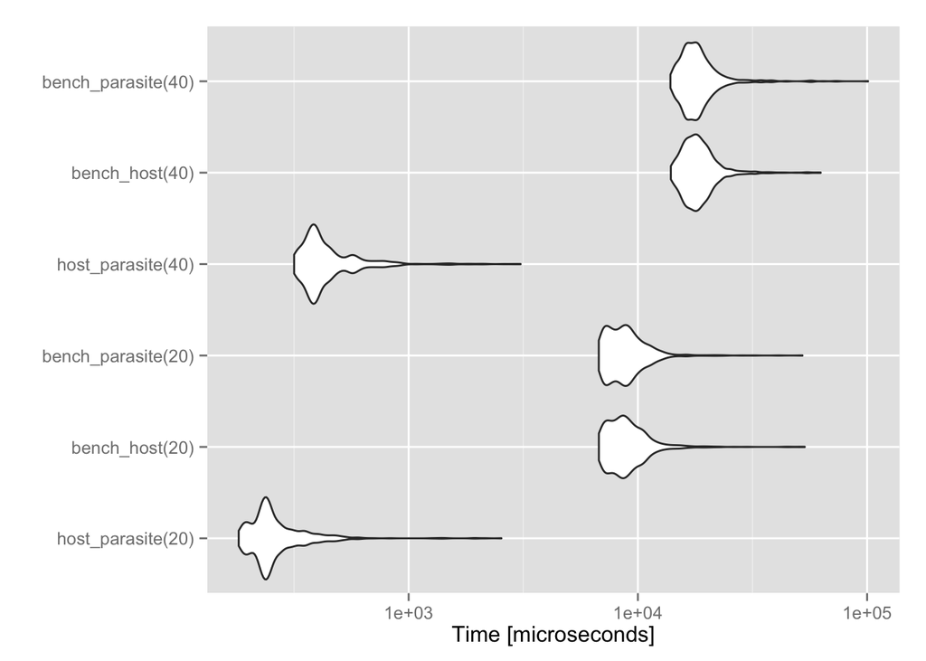

```r
autoplot(benchmarks2)
```

Now, I will explore some scenarios with some random seeds. Note that there end up being duplicate entries in our table, so there won’t be 100 plots.

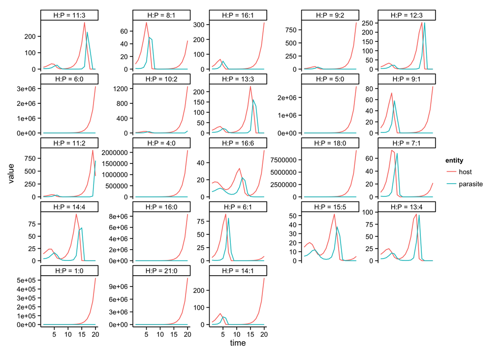

```r
set.seed(9001)
seeds <- sample(10000, 100)
hp_array <- array(dim = c(2, 20, length(seeds)),
                  dimnames = list(entity = c("host", "parasite"),
                                  time   = 1:20,
                                  seed   = NULL)
                  )
for (i in 1:length(seeds)){
  hp_array[, , i] <- host_parasite(20, seed = seeds[i])
}
dimnames(hp_array)$seed <- apply(hp_array, 3, function(x) paste0("H:P = ", x[1, 1], ":", x[2, 1]))

ggplot(melt(hp_array), aes(x = time, y = value, color = entity)) + geom_line() +
  facet_wrap(~seed, scales = "free_y") + theme_classic()
```